# MarkdownNotes

FedericaFusi

March 09, 2021

# Set up the workplace

Upload needed packages

```r
library(tidyverse)
library(tidytuesdayR)
```

Open your data

```r
tuesdata <- tidytuesdayR::tt_load(2021, week = 2)
```

```
## --- Compiling #TidyTuesday Information for 2021-01-05 ----
```

```
## --- There is 1 file available ---
```

```
## --- Starting Download ---
```

```
## --- Download complete ---
```

```r
transit_cost <- tuesdata$transit_cost
```

Have a first look at the data

```r
transit_cost
```

```
## # A tibble: 544 x 20
##        e country city  line  start_year end_year    rr length tunnel_per tunnel
##    <dbl> <chr>   <chr> <chr> <chr>      <chr>    <dbl>  <dbl> <chr>       <dbl>
##  1  7136 CA      Vanc~ Broa~ 2020       2025         0    5.7 87.72%        5
##  2  7137 CA      Toro~ Vaug~ 2009       2017         0    8.6 100.00%       8.6
##  3  7138 CA      Toro~ Scar~ 2020       2030         0    7.8 100.00%       7.8
##  4  7139 CA      Toro~ Onta~ 2020       2030         0   15.5 57.00%        8.8
##  5  7144 CA      Toro~ Yong~ 2020       2030         0    7.4 100.00%       7.4
##  6  7145 NL      Amst~ Nort~ 2003       2018         0    9.7 73.00%        7.1
##  7  7146 CA      Mont~ Blue~ 2020       2026         0    5.8 100.00%       5.8
##  8  7147 US      Seat~ U-Li~ 2009       2016         0    5.1 100.00%       5.1
##  9  7152 US      Los ~ Purp~ 2020       2027         0    4.2 100.00%       4.2
## 10  7153 US      Los ~ Purp~ 2018       2026         0    4.2 100.00%       4.2
## # ... with 534 more rows, and 10 more variables: stations <dbl>, source1 <chr>,
## #   cost <dbl>, currency <chr>, year <dbl>, ppp_rate <dbl>, real_cost <chr>,
## #   cost_km_millions <dbl>, source2 <chr>, reference <chr>
```

Check dimensions

```r
dim(transit_cost) # 544 rows and 20 columns
```

```
## [1] 544  20
```

# Cleaning

## Variables of interest

I want to look at the relationship between **length of the project** and **real cost**. My scope is to *identify those projects whose cost per km is particularly high or low*.

```r
class(transit_cost$real_cost) #character
```

```
## [1] "character"
```

```r
class(transit_cost$length) #numeric
```

```
## [1] "numeric"
```

The variable **real_cost** needs to be converted into numeric. I quickly look at it to see potential issues that might arise with the conversation.

```r
table(transit_cost$real_cost) #There seems to be a few "weird" entry that are character rather than numeric.
```

[output not shown]

[output cut: 100 more lines]

```
##          1          1          1          1          1          1          1
##    8393.88     841.12     850.38     851.21    8665.39     867.09       87.5
##          1          1          1          1          1          1          1
##     870.58    8771.32    8790.68    8825.17     883.49     885.18    8861.14
##          1          1          1          1          1          1          1
##      892.5      895.7      90000     902.29     902.71     905.41    9103.64
##          1          1          1          1          1          1          1
##     911.52    9115.68    9120.06    9141.14     919.08     9219.2    9361.08
##          1          1          1          1          1          1          1
##       9400    9465.78     948.36       9500      955.5     962.36      964.6
##          1          1          1          1          1          1          1
##       9700        988        AVG     MEDIAN        MIN          N QUARTILE 1
##          1          1          1          1          1          1          1
## QUARTILE 3        STD
##          1          1
```

I am going to check out these unusual entries by looking at the data

```r
View(transit_cost)
```

They seem to be some summary columns left in the dataset by mistake. I will remove them.

```r
transit_cost2 =
  transit_cost %>%
  filter(transit_cost$real_cost != "AVG",
         transit_cost$real_cost != "MEDIAN",
         transit_cost$real_cost != "MIN",
         transit_cost$real_cost != "N",
         transit_cost$real_cost != "QUARTILE 1",
         transit_cost$real_cost != "QUARTILE 3",
         transit_cost$real_cost != "STD")

nrow(transit_cost) - nrow(transit_cost2)
```

```
## [1] 7
```

I will check again the column to see if there are any other non-numeric data but everything seems fine.

```r
table(transit_cost2$real_cost)
```

[output not shown]

[output cut: 98 more lines]

```
##          1          1          1          1          1          1          1
##    7953.22      799.4    8023.07     808.75        810    8183.93    8369.93
##          1          1          1          1          1          1          1
##    8393.88     841.12     850.38     851.21    8665.39     867.09       87.5
##          1          1          1          1          1          1          1
##     870.58    8771.32    8790.68    8825.17     883.49     885.18    8861.14
##          1          1          1          1          1          1          1
##      892.5      895.7      90000     902.29     902.71     905.41    9103.64
##          1          1          1          1          1          1          1
##     911.52    9115.68    9120.06    9141.14     919.08     9219.2    9361.08
##          1          1          1          1          1          1          1
##       9400    9465.78     948.36       9500      955.5     962.36      964.6
##          1          1          1          1          1          1          1
##       9700        988
##          1          1
```

I will convert the variable into numeric

```r
transit_cost2$real_cost2 = as.numeric(transit_cost2$real_cost)
```

Check missing values in both variables

```r
transit_cost2 %>%
  summarise(sum(is.na(real_cost2)),
            sum(is.na(length)))
```

```
## # A tibble: 1 x 2
##   `sum(is.na(real_cost2))` `sum(is.na(length))`
##                      <int>                <int>
## 1                        0                    0
```

There aren’t any, so we are good to start the plot

### A quick note

Note what happens when we convert the original column from the original dataset

```r
transit_cost$real_cost2 = as.numeric(transit_cost$real_cost)
```

```
## Warning: NAs introduced by coercion
```

We get a warning message **Warning message: NAs introduced by coercion**. This a warning message that it is worth checking out. At a minimum you might want to inspect the column manually to see what is going on.

# My scatterplot

I will start with simple scatterplot to see how observations look like.

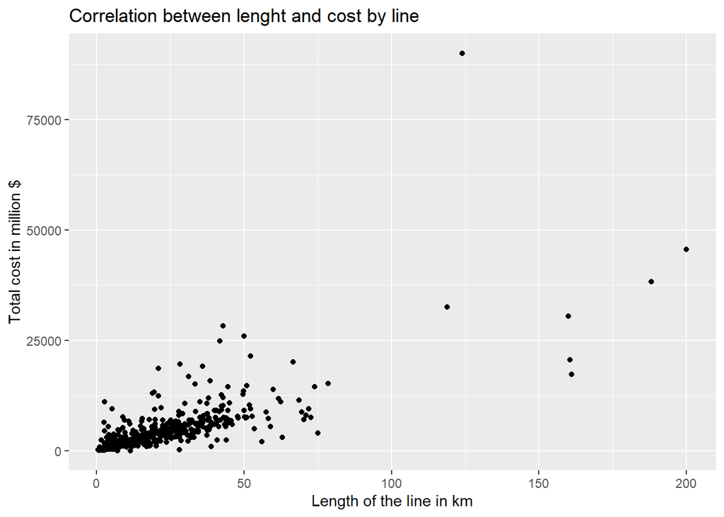

```r
transit_cost2 %>%
  ggplot() +
  geom_point(mapping = aes(y = real_cost2,
                           x = length)) +
  xlab("Length of the line in km") +
  ylab("Total cost in million $") +
  labs(title = "Correlation between lenght and cost by line")
```

There are **seven outliers** whose length of the line is greater than 100 km. These outliers reduce our attention on the vast majority of the project so I decided to remove them. I need to remember to report this information in the graph.

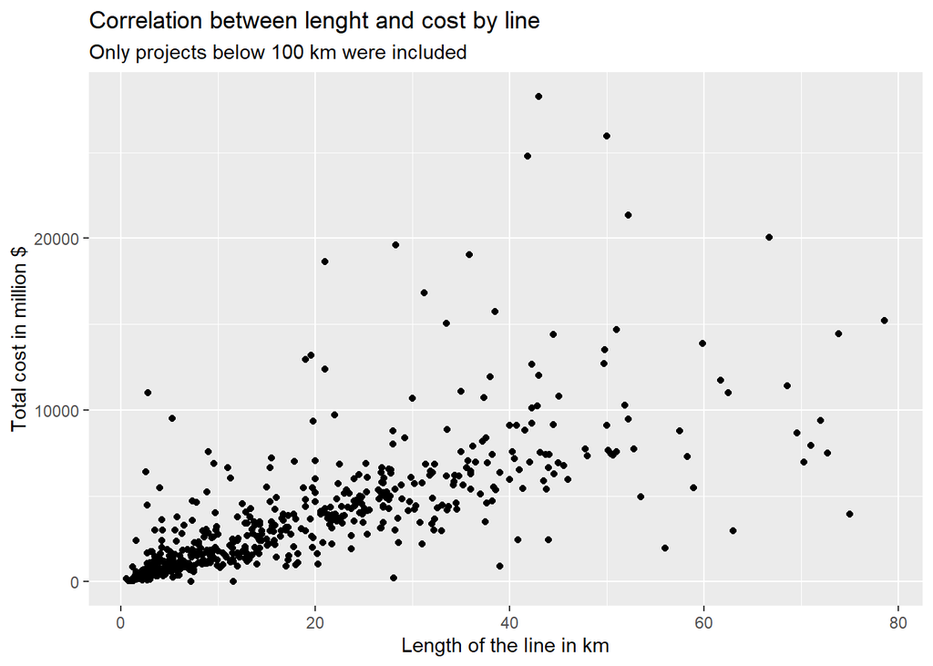

```r
transit_cost2 %>%
  filter(length <=100) %>% # Eliminate the outliers
  ggplot() +
  geom_point(mapping = aes(y = real_cost2,
                           x = length)) +
  xlab("Length of the line in km") +
  ylab("Total cost in million $") +
  labs(title = "Correlation between lenght and cost by line",
       subtitle = "Only projects below 100 km were included")
```

The graph looks much better now. I want to highlight those projects that are particularly expensive or particularly cheap. I decide to identify them as *being in the top 10 or bottom 10 quantile* considering the cost per km.

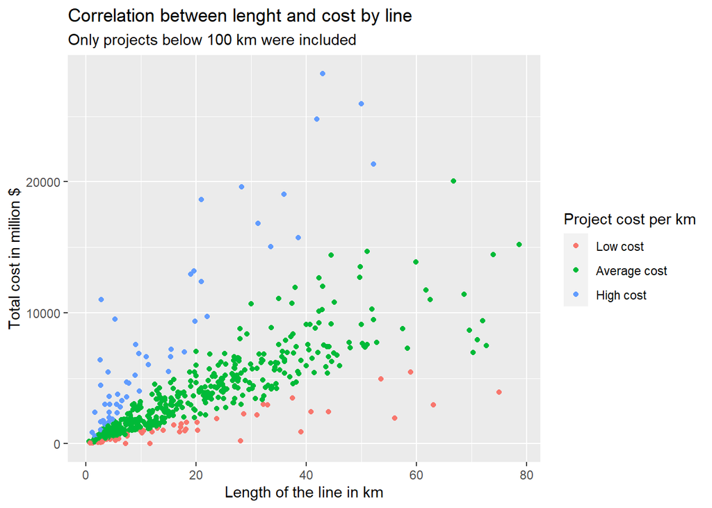

```r
transit_cost2 %>%
  filter(length <= 100) %>%

# I need to create a new variable identify the ratio cost/length
mutate(cost_km = real_cost2 / length,

# I now create a new dummy variable indicating whether the ratio is in the top 10 (=2), bottom ten (=0), or in the average (=1)
# I categorize them 0,1,2 so that the label will be ordered as low, average, high cost
         ratio_cost = ifelse(cost_km > quantile(cost_km, 0.90), 2,
                             ifelse(cost_km < quantile(cost_km, 0.10), 0, 1))) %>%

# Now I start my plot. Same as before but I add color in the aes function to color my dots based on the new cost variable
  ggplot() +
  geom_point(mapping = aes(y = real_cost2,
                           x = length,
                           color = as.character(ratio_cost))) + #Remember to change this as.character or as.factor
  xlab("Length of the line in km") +
  ylab("Total cost in million $") +
  labs(title = "Correlation between lenght and cost by line",
       subtitle = "Only projects below 100 km were included",
    # I change the legend label
       color = "Project cost per km") +
    # I change the lables of the different category using a scale. Note this is _discrete because I converted the variable into character
  scale_color_discrete(labels = c("Low cost", "Average cost", "High cost"))
```

Since I am pretty satisfied by the skeleton of my scatterplot, I can now change the graphic a bit. I want to change the color to highligh low and high cost projects and I want to add more brakes in my y_axis.

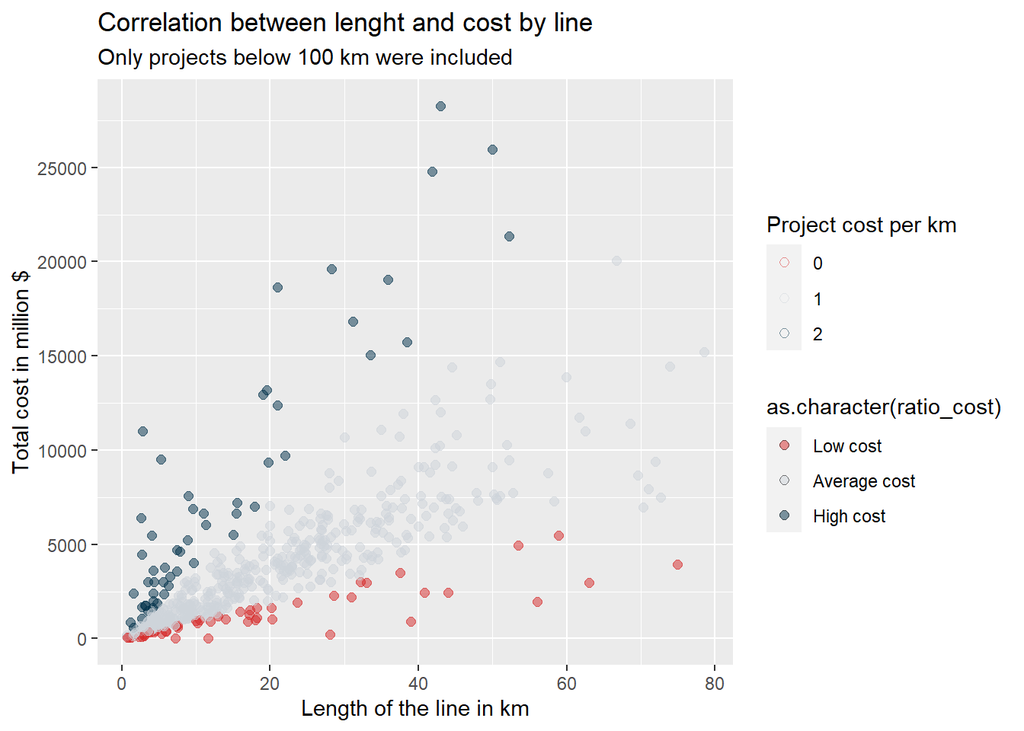

```r
transit_cost2 %>%
  filter(length <= 100) %>%

  mutate(cost_km = real_cost2 / length,
           ratio_cost = ifelse(cost_km > quantile(cost_km, 0.90), 2,
                             ifelse(cost_km < quantile(cost_km, 0.10), 0, 1))) %>%
  ggplot() +
  geom_point(mapping = aes(y = real_cost2,
                           x = length,
                           fill = as.character(ratio_cost),
                           color = as.character(ratio_cost)),
             size = 2,
             shape = 21,
             alpha = 0.5) +
  xlab("Length of the line in km") +
  ylab("Total cost in million $") +
  labs(title = "Correlation between lenght and cost by line",
       subtitle = "Only projects below 100 km were included",
       color = "Project cost per km") +
  # Changing color to make
  scale_fill_manual(values = c("#d62828", "#ced4da", "#003049"),
                     labels = c("Low cost", "Average cost", "High cost")) +
  scale_color_manual(values = c("#d62828", "#ced4da", "#003049")) +
  scale_y_continuous(breaks = seq(0, 30000, by = 5000))
```